# Swiss Taxes

Leo Franco

4 Apr 2017

# Swiss Taxes

The idea of this project is to show different tax rates in Switzerland. These rates vary according to canton (state or region) and according to the particulars of the person (civil state, number of kids, etc).

You can find the app in https://leofranco.shinyapps.io/SwissTaxes/. This is useful if you are new to Switzerland and would like to choose where to live to minimize the amount of taxes paid. Please note that this should not be the only criteria to choose a place to live. Also, please keep in mind that this information doesn’t constitute any advice. It has been summarized from public sources and it is intended for educational purposes only.

# Single person with no kids earning CHF 10,000 a month.

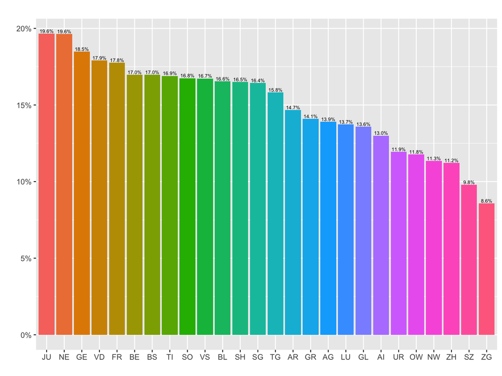

Best place to live is Zug with a tax rate of 8.6%

# Married couple with 3 kids earning CHF 5,000 a month.

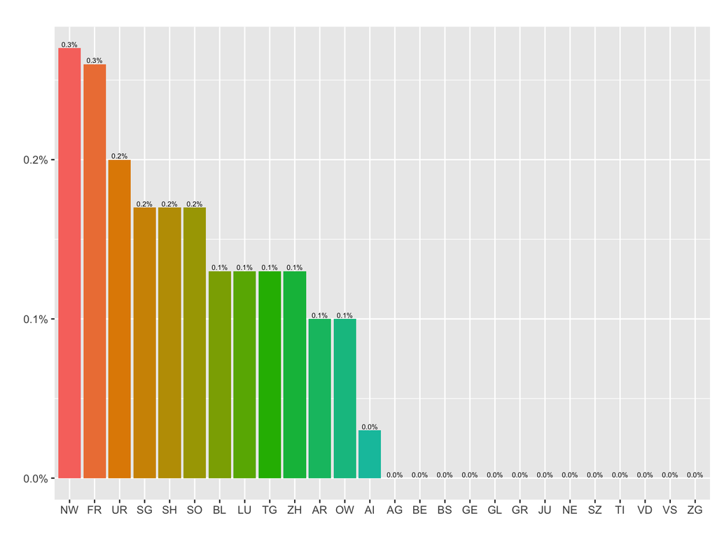

There are multiple cantons where this couple would pay no taxes at all.

# Conclusion

With this simple app we can analyze different tax rates and decide what is the best place to live based on this criteria. For instance, a single person earning 10,000 francs a month would pay 8.6% if living in Zug but 19.6% if living in Jura. There is only 1.5 hours between then and some people would choose to commute in order to save 1,100 francs every month.